# DengueAI: EDA and Cleaning

```python
# import the relevant tools
import pandas as pd
import numpy as np
import matplotlib.pyplot as plt
import seaborn as sns
from sklearn.preprocessing import StandardScaler
import warnings
warnings.filterwarnings("ignore")
%matplotlib inline
```

**General File Structure**:

- `Training features`
  - This data will be split into a training set and a validation set to tune the model as the final metric will be predicting from the test data to then submit for a competition score (MAE).
- `Testing features`
  - This is the data that will be fed through a tuned ML model for submission to the competition and ranking, and will serve as the overall makrer for progress.
- S`ubmision format`
  - The is the output format expected by the competition.

**Features**:

```python
# examine the feature set, and check for any missing values
df_train = pd.read_csv('data/dengue_features_train.csv', parse_dates=[3])
print('# Missing:', df_train.isnull().any().sum() )
print('df shape:', df_train.shape)
df_train.head()
```

```
# Missing: 20
df shape: (1456, 24)
```

|  | city | year | weekofyear | week_start_date | ndvi_ne | ndvi_nw | ndvi_se | ndvi_sw | precipitation_amt_mm | reanalysis_air_temp_k | ... | reanalysis_precip_amt_kg_per_m2 | reanalysis_relative_humidity_percent | reanalysis_sat_precip_amt_mm | reanalysis_specific_humidity_g_per_kg | reanalysis_tdtr_k | station_avg_temp_c | station_diur_temp_rng_c | station_max_temp_c | station_min_temp_c | station_precip_mm |
| --- | --- | --- | --- | --- | --- | --- | --- | --- | --- | --- | --- | --- | --- | --- | --- | --- | --- | --- | --- | --- | --- |
| 0 | sj | 1990 | 18 | 1990-04-30 | 0.122600 | 0.103725 | 0.198483 | 0.177617 | 12.42 | 297.572857 | ... | 32.00 | 73.365714 | 12.42 | 14.012857 | 2.628571 | 25.442857 | 6.900000 | 29.4 | 20.0 | 16.0 |
| 1 | sj | 1990 | 19 | 1990-05-07 | 0.169900 | 0.142175 | 0.162357 | 0.155486 | 22.82 | 298.211429 | ... | 17.94 | 77.368571 | 22.82 | 15.372857 | 2.371429 | 26.714286 | 6.371429 | 31.7 | 22.2 | 8.6 |
| 2 | sj | 1990 | 20 | 1990-05-14 | 0.032250 | 0.172967 | 0.157200 | 0.170843 | 34.54 | 298.781429 | ... | 26.10 | 82.052857 | 34.54 | 16.848571 | 2.300000 | 26.714286 | 6.485714 | 32.2 | 22.8 | 41.4 |
| 3 | sj | 1990 | 21 | 1990-05-21 | 0.128633 | 0.245067 | 0.227557 | 0.235886 | 15.36 | 298.987143 | ... | 13.90 | 80.337143 | 15.36 | 16.672857 | 2.428571 | 27.471429 | 6.771429 | 33.3 | 23.3 | 4.0 |
| 4 | sj | 1990 | 22 | 1990-05-28 | 0.196200 | 0.262200 | 0.251200 | 0.247340 | 7.52 | 299.518571 | ... | 12.20 | 80.460000 | 7.52 | 17.210000 | 3.014286 | 28.942857 | 9.371429 | 35.0 | 23.9 | 5.8 |

5 rows × 24 columns

```python
# take a look at the target data
target = pd.read_csv('data/dengue_labels_train.csv')
print('# Missing:', target.isnull().any().sum() )
print('df shape:', target.shape)
target.head()
```

```
# Missing: 0
df shape: (1456, 4)
```

|  | city | year | weekofyear | total_cases |
| --- | --- | --- | --- | --- |
| 0 | sj | 1990 | 18 | 4 |
| 1 | sj | 1990 | 19 | 5 |
| 2 | sj | 1990 | 20 | 4 |
| 3 | sj | 1990 | 21 | 3 |
| 4 | sj | 1990 | 22 | 6 |

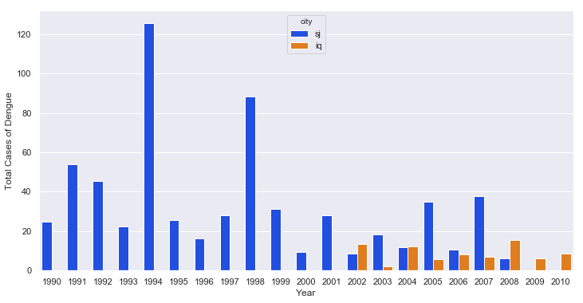

```python
#Visualizing the year distribution by city
sns.set(style="darkgrid", palette="bright")
plt.figure(figsize=(12,6))
sns.barplot(x='year', y='total_cases', hue='city', ci=None, data=target)
plt.xlabel('Year')
plt.ylabel('Total Cases of Dengue');
```

```python
# merge to plot some addition comparisons of the data
train_merge = pd.merge(target, df_train, on=['city','year','weekofyear'])
train_merge.head()
```

|  | city | year | weekofyear | total_cases | week_start_date | ndvi_ne | ndvi_nw | ndvi_se | ndvi_sw | precipitation_amt_mm | ... | reanalysis_precip_amt_kg_per_m2 | reanalysis_relative_humidity_percent | reanalysis_sat_precip_amt_mm | reanalysis_specific_humidity_g_per_kg | reanalysis_tdtr_k | station_avg_temp_c | station_diur_temp_rng_c | station_max_temp_c | station_min_temp_c | station_precip_mm |
| --- | --- | --- | --- | --- | --- | --- | --- | --- | --- | --- | --- | --- | --- | --- | --- | --- | --- | --- | --- | --- | --- |
| 0 | sj | 1990 | 18 | 4 | 1990-04-30 | 0.122600 | 0.103725 | 0.198483 | 0.177617 | 12.42 | ... | 32.00 | 73.365714 | 12.42 | 14.012857 | 2.628571 | 25.442857 | 6.900000 | 29.4 | 20.0 | 16.0 |
| 1 | sj | 1990 | 19 | 5 | 1990-05-07 | 0.169900 | 0.142175 | 0.162357 | 0.155486 | 22.82 | ... | 17.94 | 77.368571 | 22.82 | 15.372857 | 2.371429 | 26.714286 | 6.371429 | 31.7 | 22.2 | 8.6 |
| 2 | sj | 1990 | 20 | 4 | 1990-05-14 | 0.032250 | 0.172967 | 0.157200 | 0.170843 | 34.54 | ... | 26.10 | 82.052857 | 34.54 | 16.848571 | 2.300000 | 26.714286 | 6.485714 | 32.2 | 22.8 | 41.4 |
| 3 | sj | 1990 | 21 | 3 | 1990-05-21 | 0.128633 | 0.245067 | 0.227557 | 0.235886 | 15.36 | ... | 13.90 | 80.337143 | 15.36 | 16.672857 | 2.428571 | 27.471429 | 6.771429 | 33.3 | 23.3 | 4.0 |
| 4 | sj | 1990 | 22 | 6 | 1990-05-28 | 0.196200 | 0.262200 | 0.251200 | 0.247340 | 7.52 | ... | 12.20 | 80.460000 | 7.52 | 17.210000 | 3.014286 | 28.942857 | 9.371429 | 35.0 | 23.9 | 5.8 |

5 rows × 25 columns

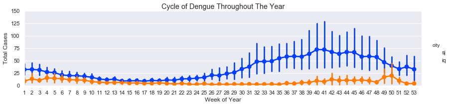

```python
sns.set(style="darkgrid", palette="bright")
fig = sns.FacetGrid(train_merge, hue='city', aspect=4)
fig.map(sns.pointplot,'weekofyear','total_cases')
max_x = train_merge.weekofyear.max()
# min_x = train_merge.weekofyear.min()
fig.set(xlim=(0,max_x))
fig.set(ylim=(0, 150))
fig.set(xlabel='Week of Year')
fig.set(ylabel='Total Cases')
fig.add_legend()
fig.fig.suptitle("Cycle of Dengue Throughout The Year");
```

```
(0, 0.09)
```

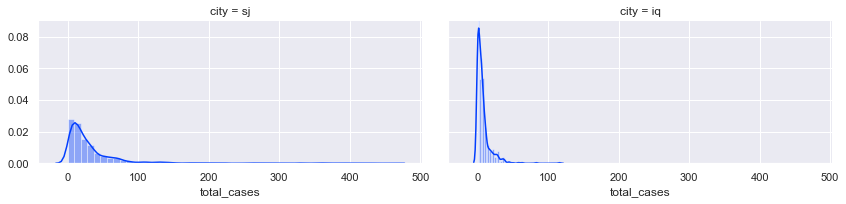

```python
#Lets check the total cases of Dengue in the city's
sns.set(style="darkgrid", palette="bright")
g = sns.FacetGrid(train_merge, col="city",aspect=2)
g.map(sns.distplot, "total_cases")
axes = g.axes
axes[0,0].set_ylim(0,0.090)
axes[0,1].set_ylim(0,0.090)
```

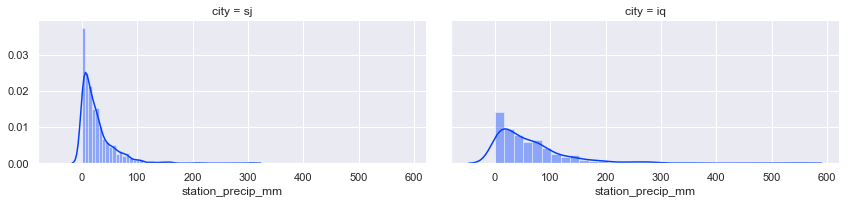

```python
#Lets check the station_precip_mm in the city's
sns.set(style="darkgrid", palette="bright")
g = sns.FacetGrid(train_merge, col="city",aspect=2)
g.map(sns.distplot, "station_precip_mm")
```

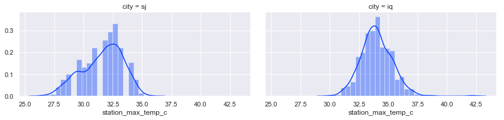

```python
#Lets check the station_max_temp_c in the city's
sns.set(style="darkgrid", palette="bright")
g = sns.FacetGrid(train_merge, col="city",aspect=2)
g.map(sns.distplot, "station_max_temp_c")
```

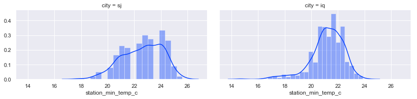

```python
#Lets check the station_min_temp_c in the city's
sns.set(style="darkgrid", palette="bright")
g = sns.FacetGrid(train_merge, col="city",aspect=2)
g.map(sns.distplot, "station_min_temp_c")
```

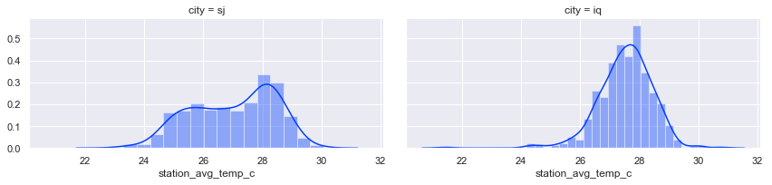

```python
#Lets check the station_avg_temp_c in the city's
sns.set(style="darkgrid", palette="bright")
g = sns.FacetGrid(train_merge, col="city",aspect=2)
g.map(sns.distplot, "station_avg_temp_c")
```

### Examine the missing data

```python
# missing data for the training data
df_train.isnull().sum()
```

```
city                                       0
year                                       0
weekofyear                                 0
week_start_date                            0
ndvi_ne                                  194
ndvi_nw                                   52
ndvi_se                                   22
ndvi_sw                                   22
precipitation_amt_mm                      13
reanalysis_air_temp_k                     10
reanalysis_avg_temp_k                     10
reanalysis_dew_point_temp_k               10
reanalysis_max_air_temp_k                 10
reanalysis_min_air_temp_k                 10
reanalysis_precip_amt_kg_per_m2           10
reanalysis_relative_humidity_percent      10
reanalysis_sat_precip_amt_mm              13
reanalysis_specific_humidity_g_per_kg     10
reanalysis_tdtr_k                         10
station_avg_temp_c                        43
station_diur_temp_rng_c                   43
station_max_temp_c                        20
station_min_temp_c                        14
station_precip_mm                         22
dtype: int64
```

```python
# missing values for the testing features
df_test = pd.read_csv('dengue_features_test.csv')
df_test.isnull().sum()
```

[output not shown]

So, know that we have established that there are missing data, how should we progress? This seems to be one of the perienial questions of data science. Missing data in real-world scenarios in simply a fact of life (and representative of it). In this case I will be imputing the missing variables as the do not reperesent a significant proportion of the data fields and any real-world delployable pipeline would beed the ability to cope with missing data points. Further, as we are dealing with semi-continuous field like rain fall and temperature this is not an uncommon or inaccuate practice. Imputing data is obviously not a perfect solution and does hender the absolute (theoretical output of the model) but in this case I think the belefits outweight the risks. Plus, if the model is not performing well durring validation we can always return to this point and use another or modified solution.

Given that we are working with two distinct geographic locations it will be necessary to split the feature data for imputing.

```python
df_sj = df_train[df_train['city'] == 'sj']
print('sj', df_sj.shape)
df_iq = df_train[df_train['city'] == 'iq']
print('iq', df_iq.shape)
```

```
sj (936, 24)
iq (520, 24)
```

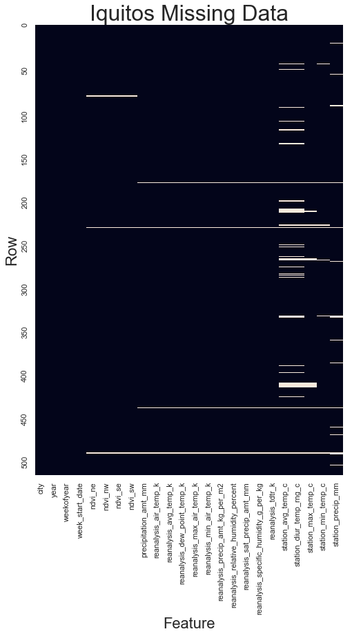

```python
# viz missing data

fig, ax = plt.subplots(figsize=(8,12))
sns.heatmap(df_iq.isnull().reset_index(drop=True),ax=ax, cbar = False, yticklabels = 50)

plt.ylabel("Row", size = 22)
plt.xlabel("Feature", size = 22)
plt.title("Iquitos Missing Data", size = 32)
```

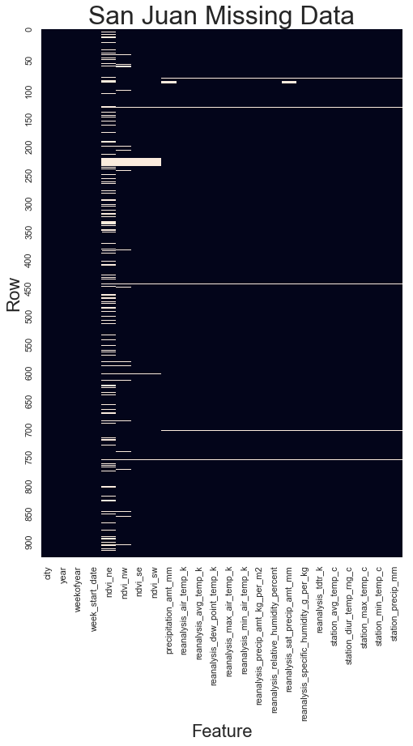

```python
# viz missing data

fig, ax = plt.subplots(figsize=(8,12))
sns.heatmap(df_sj.isnull(),ax=ax, cbar = False, yticklabels = 50)

plt.ylabel("Row", size = 22)
plt.xlabel("Feature", size = 22)
plt.title("San Juan Missing Data", size = 32)
```

Given the semi-continuous nature of many of these features and the seasonal shift in many of them e.g. rainfall it makes more sense to use a forward or backfill approach from the nearest value rather than a mean or median approach. This is unless we wish to get into a much more intensive imputing process which would account for seasonal i.e. monthly averages. For now, I will save that for another time.

```python
df_sj = df_sj.fillna(method = 'ffill')
df_iq = df_iq.fillna(method = 'ffill')
print('San Juan:',df_sj.isnull().any().sum())
print('Iquitos:',df_iq.isnull().any().sum())
```

```
San Juan: 0
Iquitos: 0
```

```python
df_sj.info()
```

```
<class 'pandas.core.frame.DataFrame'>
Int64Index: 936 entries, 0 to 935
Data columns (total 24 columns):
city                                     936 non-null object
year                                     936 non-null int64
weekofyear                               936 non-null int64
week_start_date                          936 non-null datetime64[ns]
ndvi_ne                                  936 non-null float64
ndvi_nw                                  936 non-null float64
ndvi_se                                  936 non-null float64
ndvi_sw                                  936 non-null float64
precipitation_amt_mm                     936 non-null float64
reanalysis_air_temp_k                    936 non-null float64
reanalysis_avg_temp_k                    936 non-null float64
reanalysis_dew_point_temp_k              936 non-null float64
reanalysis_max_air_temp_k                936 non-null float64
reanalysis_min_air_temp_k                936 non-null float64
reanalysis_precip_amt_kg_per_m2          936 non-null float64
reanalysis_relative_humidity_percent     936 non-null float64
reanalysis_sat_precip_amt_mm             936 non-null float64
reanalysis_specific_humidity_g_per_kg    936 non-null float64
reanalysis_tdtr_k                        936 non-null float64
station_avg_temp_c                       936 non-null float64
station_diur_temp_rng_c                  936 non-null float64
station_max_temp_c                       936 non-null float64
station_min_temp_c                       936 non-null float64
station_precip_mm                        936 non-null float64
dtypes: datetime64[ns](1), float64(20), int64(2), object(1)
memory usage: 182.8+ KB
```

Now that our feature set is mostly cleaned-up, lets take a closer look at the target data.

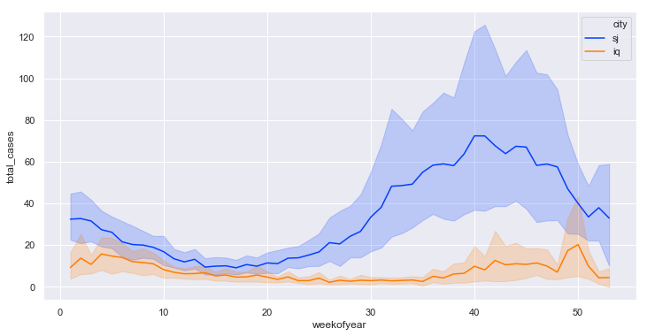

```python
# let take anothe look at the weekly fluctuation in each city
plt.figure(figsize=(12,6))
sns.lineplot(x='weekofyear', y='total_cases', data=target, hue='city')
```

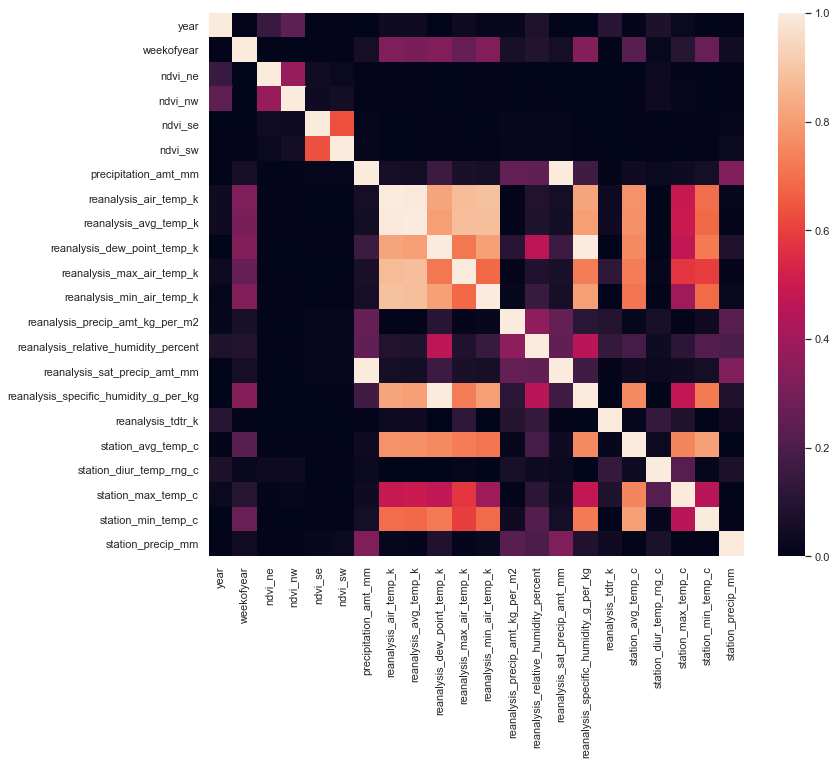

```python
plt.figure(figsize=(12,10))
sns.heatmap(df_sj.corr()**2)
```

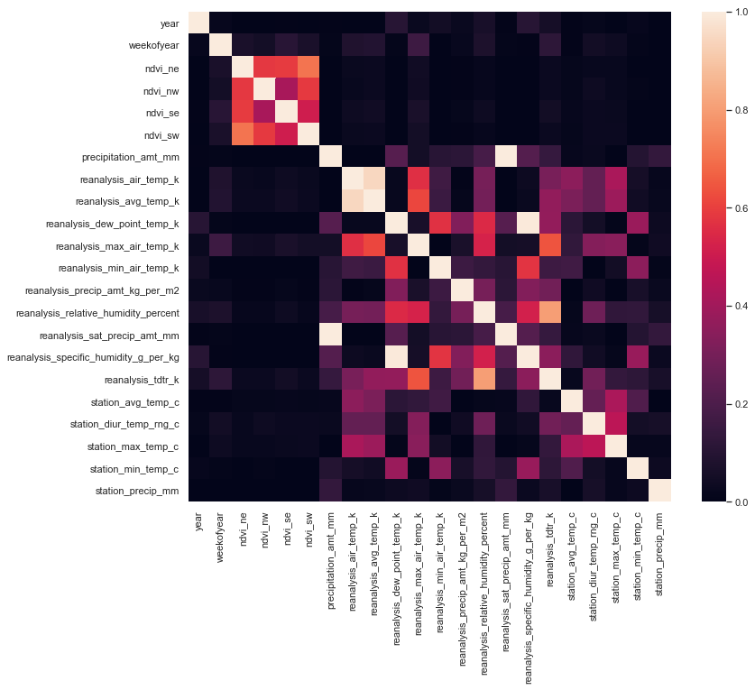

```python
plt.figure(figsize=(12,10))
sns.heatmap(df_iq.corr()**2)
```

```python
df_sj.set_index('week_start_date', drop = True, inplace = True)
df_iq.set_index('week_start_date', drop = True, inplace = True)
df_sj['nvdi_mean'] = df_sj[df_sj.columns[3:7]].mean(axis = 1)
df_iq['nvdi_mean'] = df_iq[df_iq.columns[3:7]].mean(axis = 1)
```

```python
df_sj.info()
```

```
<class 'pandas.core.frame.DataFrame'>
DatetimeIndex: 936 entries, 1990-04-30 to 2008-04-22
Data columns (total 24 columns):
city                                     936 non-null object
year                                     936 non-null int64
weekofyear                               936 non-null int64
ndvi_ne                                  936 non-null float64
ndvi_nw                                  936 non-null float64
ndvi_se                                  936 non-null float64
ndvi_sw                                  936 non-null float64
precipitation_amt_mm                     936 non-null float64
reanalysis_air_temp_k                    936 non-null float64
reanalysis_avg_temp_k                    936 non-null float64
reanalysis_dew_point_temp_k              936 non-null float64
reanalysis_max_air_temp_k                936 non-null float64
reanalysis_min_air_temp_k                936 non-null float64
reanalysis_precip_amt_kg_per_m2          936 non-null float64
reanalysis_relative_humidity_percent     936 non-null float64
reanalysis_sat_precip_amt_mm             936 non-null float64
reanalysis_specific_humidity_g_per_kg    936 non-null float64
reanalysis_tdtr_k                        936 non-null float64
station_avg_temp_c                       936 non-null float64
station_diur_temp_rng_c                  936 non-null float64
station_max_temp_c                       936 non-null float64
station_min_temp_c                       936 non-null float64
station_precip_mm                        936 non-null float64
nvdi_mean                                936 non-null float64
dtypes: float64(21), int64(2), object(1)
memory usage: 182.8+ KB
```

```
No handles with labels found to put in legend.
```

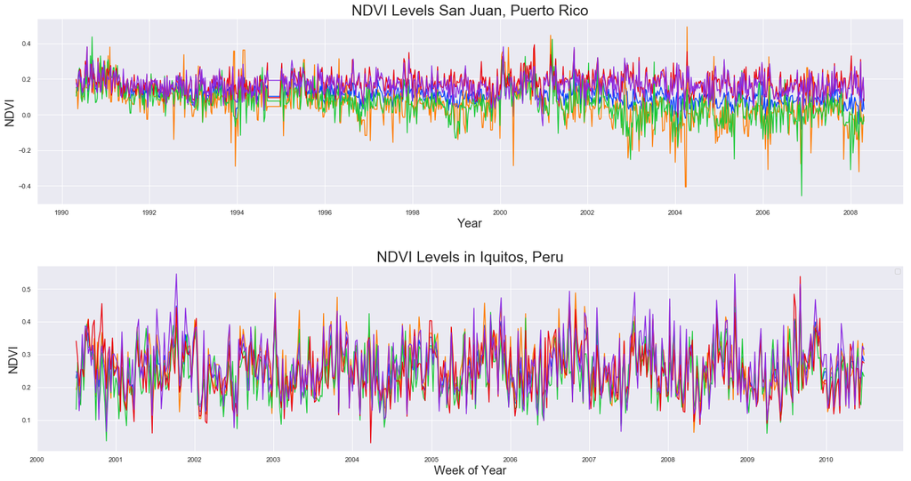

```python
# plot week by week and yearly average for San Juan
fig, ax = plt.subplots(2, 1, figsize=(22, 12))

ndvi_cols = ['nvdi_mean', 'ndvi_ne', 'ndvi_nw', 'ndvi_se', 'ndvi_sw']

#top plot
plt.subplot(211)
for i in ndvi_cols:
    sns.lineplot(y=df_sj[i], x=df_sj.index, data=df_sj, markers=True)
plt.title('NDVI Levels San Juan, Puerto Rico', size = 25)
plt.xlabel('Year', size = 20)
plt.ylabel('NDVI', size = 20)

# bottom plot
plt.subplot(212)
for i in ndvi_cols:
    sns.lineplot(y=df_iq[i], x=df_iq.index, data=df_iq, markers=True)
plt.title('NDVI Levels in Iquitos, Peru', size = 25)
plt.xlabel('Week of Year', size = 20)
plt.ylabel('NDVI', size = 20)
plt.legend(loc = 'best')

plt.tight_layout(pad=3)
```

```python
# re-load and re-process the data to ensure a clean output
df = pd.read_csv('data/dengue_features_train.csv', parse_dates=[3])
target = pd.read_csv('data/dengue_labels_train.csv')

# merge on the target variable
df['total_cases'] = target['total_cases']

# split by city
df_sj = df[df['city'] == 'sj']
df_iq = df[df['city'] == 'iq']

## forward fill the mising values
df_sj = df_sj.fillna(method = 'ffill')
df_iq = df_iq.fillna(method = 'ffill')

#drop non-numerical values
df_sj.drop(['city', 'year'], axis = 1, inplace = True)
df_iq.drop(['city', 'year'], axis = 1, inplace = True)

# export the cleaned data to csv
df_iq.to_csv(path_or_buf='df_iq.csv', index=False)
df_sj.to_csv(path_or_buf='df_sj.csv', index=False)
```

```python
df_sj.head()
```

|  | weekofyear | week_start_date | ndvi_ne | ndvi_nw | ndvi_se | ndvi_sw | precipitation_amt_mm | reanalysis_air_temp_k | reanalysis_avg_temp_k | reanalysis_dew_point_temp_k | ... | reanalysis_relative_humidity_percent | reanalysis_sat_precip_amt_mm | reanalysis_specific_humidity_g_per_kg | reanalysis_tdtr_k | station_avg_temp_c | station_diur_temp_rng_c | station_max_temp_c | station_min_temp_c | station_precip_mm | total_cases |
| --- | --- | --- | --- | --- | --- | --- | --- | --- | --- | --- | --- | --- | --- | --- | --- | --- | --- | --- | --- | --- | --- |
| 0 | 18 | 1990-04-30 | 0.122600 | 0.103725 | 0.198483 | 0.177617 | 12.42 | 297.572857 | 297.742857 | 292.414286 | ... | 73.365714 | 12.42 | 14.012857 | 2.628571 | 25.442857 | 6.900000 | 29.4 | 20.0 | 16.0 | 4 |
| 1 | 19 | 1990-05-07 | 0.169900 | 0.142175 | 0.162357 | 0.155486 | 22.82 | 298.211429 | 298.442857 | 293.951429 | ... | 77.368571 | 22.82 | 15.372857 | 2.371429 | 26.714286 | 6.371429 | 31.7 | 22.2 | 8.6 | 5 |
| 2 | 20 | 1990-05-14 | 0.032250 | 0.172967 | 0.157200 | 0.170843 | 34.54 | 298.781429 | 298.878571 | 295.434286 | ... | 82.052857 | 34.54 | 16.848571 | 2.300000 | 26.714286 | 6.485714 | 32.2 | 22.8 | 41.4 | 4 |
| 3 | 21 | 1990-05-21 | 0.128633 | 0.245067 | 0.227557 | 0.235886 | 15.36 | 298.987143 | 299.228571 | 295.310000 | ... | 80.337143 | 15.36 | 16.672857 | 2.428571 | 27.471429 | 6.771429 | 33.3 | 23.3 | 4.0 | 3 |
| 4 | 22 | 1990-05-28 | 0.196200 | 0.262200 | 0.251200 | 0.247340 | 7.52 | 299.518571 | 299.664286 | 295.821429 | ... | 80.460000 | 7.52 | 17.210000 | 3.014286 | 28.942857 | 9.371429 | 35.0 | 23.9 | 5.8 | 6 |

5 rows × 23 columns